# Лабораторная работа №4

Продвинутое использование git

Автор

принадлежность

Юсупова Амина Руслановна

Российский университет дружбы народов

# Цели и задачи работы

## Цель лабораторной работы

Получение навыков правильной работы с репозиториями git.

# Процесс выполнения лабораторной работы

## Установка Git Flow

Для управления ветками было установлено расширение Git Flow. Репозиторий Copr включён, пакет установлен.

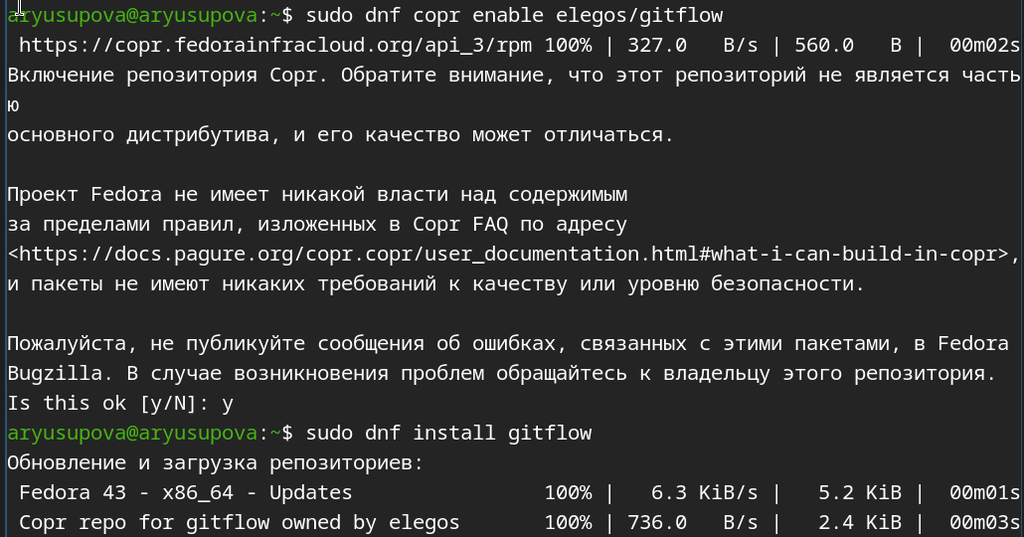

Установка Git Flow

## Установка Node.js и pnpm

Node.js необходим для работы пакетного менеджера pnpm, который используется для установки Commitizen. После установки выполнена настройка окружения.

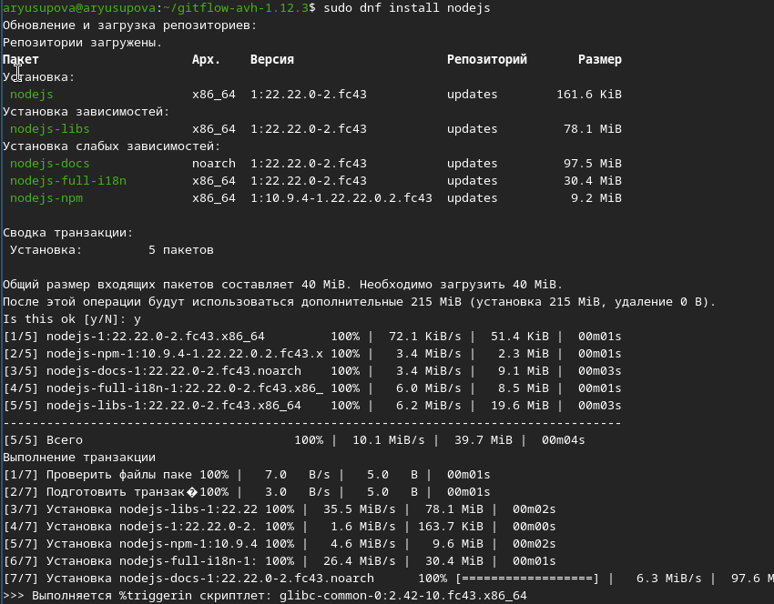

Установка Node.js

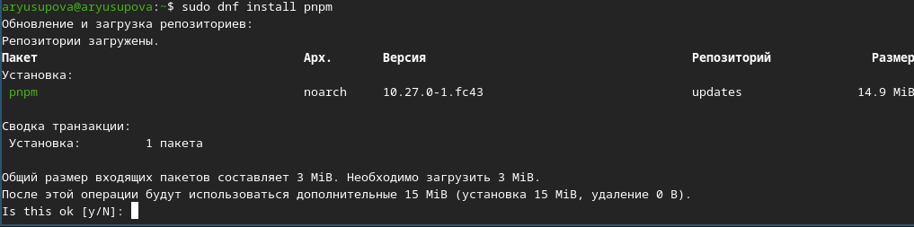

Установка pnpm

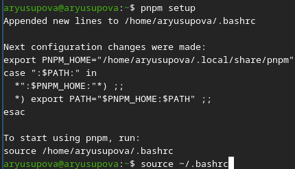

Настройка pnpm

## Создание репозитория и первый push

Создан локальный репозиторий `git-extended`, добавлен файл `README.md`, выполнена привязка к удалённому репозиторию на GitHub и произведён первый push.

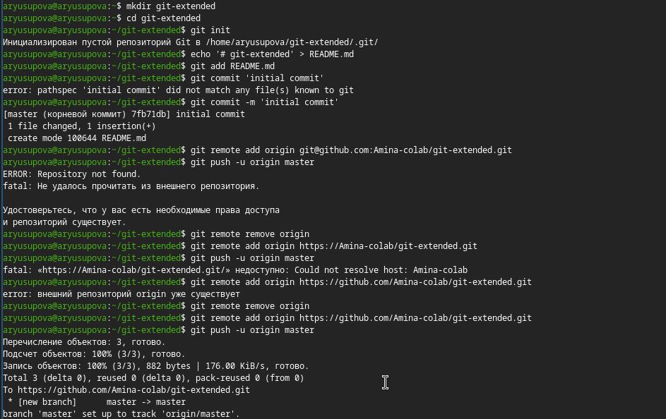

Связь с GitHub

## Инициализация Git Flow

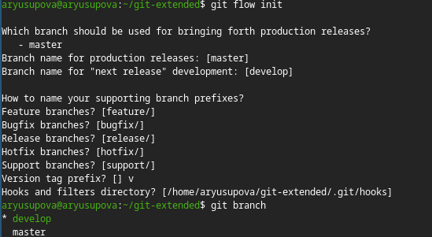

Инициализация Git Flow

## Отправка ветки develop

Ветка `develop` отправлена на сервер и настроена на отслеживание удалённой ветки.

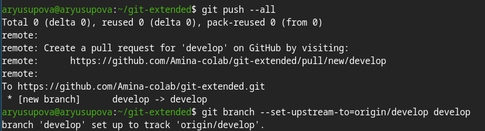

Отправка develop

## Настройка package.json и Commitizen

Создан файл `package.json` через `pnpm init`, отредактирован: добавлено описание, автор, лицензия, настроен Commitizen для конвенциональных коммитов.

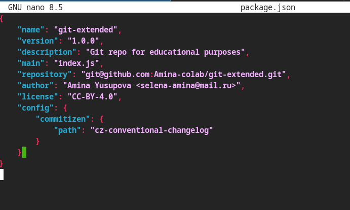

Редактирование package.json

Коммит выполнен с помощью `git cz`, что обеспечило соблюдение стандарта Conventional Commits.

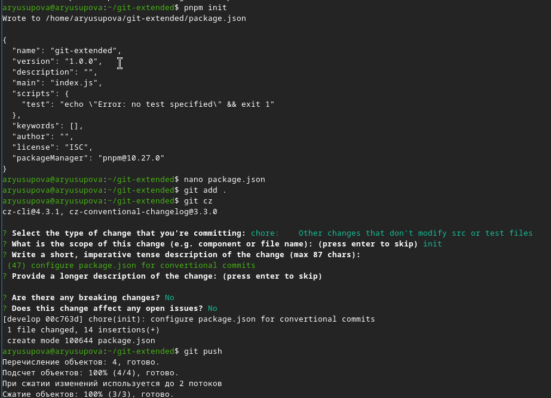

Коммит через git cz

## Создание первого релиза (v1.0.0)

Создана релизная ветка, сгенерирован `CHANGELOG.md` с помощью `standard-changelog`. Релиз завершён, тег создан вручную из-за ошибки автоматического создания.

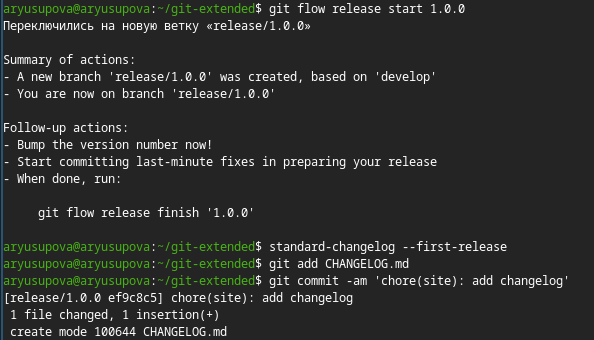

Генерация changelog

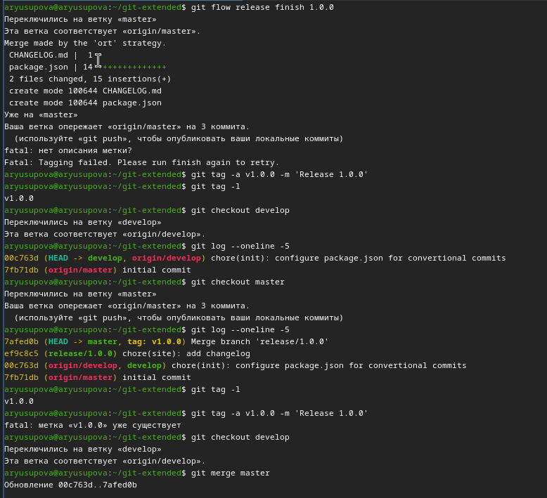

Завершение релиза и создание тега

Ветки и теги отправлены на GitHub, релиз опубликован через `gh release create`.

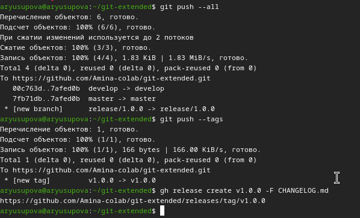

Публикация релиза

## Работа с feature-веткой

Создана feature-ветка, в неё добавлен файл `example.txt`, сделан коммит через `git cz`. После завершения ветка слита в `develop`.

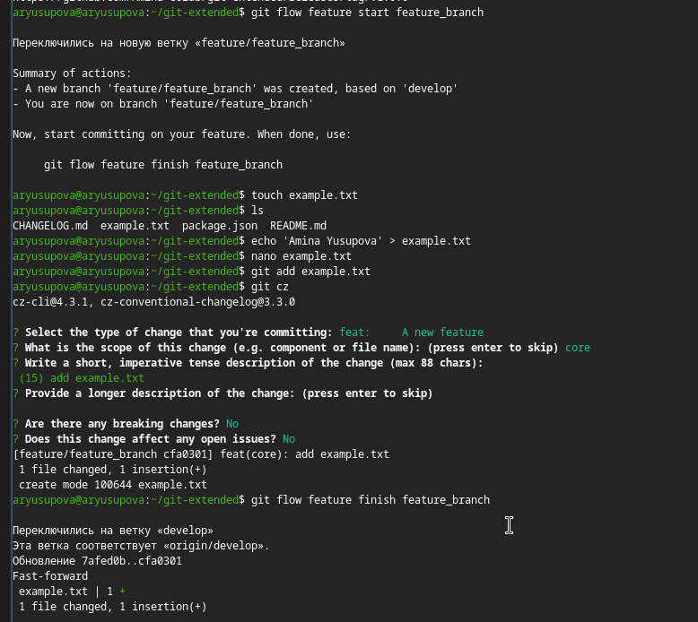

Создание feature-ветки

## Создание второго релиза (v1.2.3)

Аналогично первому релизу создана ветка `release/1.2.3`, обновлён `CHANGELOG.md`. При завершении снова возникла ошибка с тегом, но слияние прошло успешно. Релиз создан на GitHub.

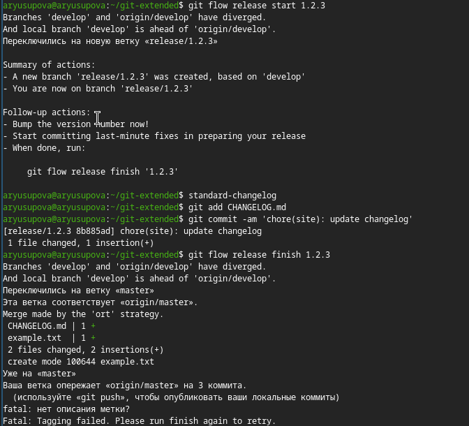

Подготовка второго релиза

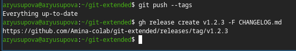

Публикация второго релиза

# Выводы по проделанной работе

## Вывод

В ходе выполнения лабораторной работы были освоены основные приёмы работы с Git Flow:

- установка и настройка инструментов (Git Flow, Node.js, pnpm, Commitizen);
- инициализация репозитория с ветками `master` и `develop`;
- создание и завершение feature-веток;
- подготовка и публикация релизов с автоматической генерацией changelog;
- использование конвенциональных коммитов через Commitizen.